# DataScience_1Assignment

Gary Leander

17/11/2020

```r
library(tidyverse)
```

```r
library(ggplot2)
library(dplyr)
```

# Data Science with R: Assignment Task

## 1. BASICS

### 1.1. Variables in R

What is the value of " B " after running these command? [2]

```r
a <- 5.0
c <- 10
t <- 12
B <- a+c/t
```

The value of B is : 5.83

What type of vector do you get in each of the following? [4]

```r
vec_1 <- c(44, 5, 0, "k")
vec_2 <- c(1, 2, 3, FALSE)
vec_3 <- c("a", "b", "c", TRUE)
vec_4 <- c(1, 2, 3, "4")
```

```r
vectype1<-typeof(vec_1)
vectype2<-typeof(vec_2)
vectype3<-typeof(vec_3)
vectype4<-typeof(vec_4)
```

vec_1 is a character type of vector.

vec_2 is a double type of vector.

vec_3 is a character type of vector.

vec_4 is a character type of vector.

### 1.2. Conditional subsetting

Consider the following vector:

```r
vec <- c(141.2741, 141.8392, 140.5730,NA, 141.3571, 139.8689, 137.9384, NA,139.6620, 138.2521, 138.8635, 141.3885, NA)

vec_1<-vec
vec_1<-c(na.omit(vec))
```

141.2741, 141.8392, 140.573, 141.3571, 139.8689, 137.9384, 139.662, 138.2521, 138.8635, 141.3885

vec_1 is formed by checking where in the vector “vec” there are missing values in the form “NA” and all those values are omitted through the “na.omit()” function.

#### 1.2.2. Create a vector of indexes of missing values using conditional subsetting and explain your code [3]

```r
x<-c(which(vec %in% NA))
```

4, 8, 13

The code checks at which position NA appears in the original vector “vec” through the which() function and uses the positions as values for the new vector “x”

#### 1.2.3. Write a code to determine how many missing values are in vec. [2]

```r
AmtMissing<-sum(is.na(vec))
```

There are 3 missing values in “vec”

#### 1.2.4. Write a R code to create a data frame which contains details of 3 students as follows: [4]

- Name
- Surname
- Age
- Gender

```r
df<- data.frame("Name"=c("Name1","Name2","Name3"),"Surname"=c("Surname1","Surname2","Surname3"),"Age"=c(1,2,3),"Gender"=c("Male","Female","Female"))
```

## 2. Functions in R

### 2.1. Create a function which returns a mean of an input vector and explain your code

```r
#x<-c()
meanVal <-function(x){
  a<-sum(x)
  b<-length(x)
  return(a/b)

}
x<-c(1,2,3,4)
meanVal(x)
```

```
## [1] 2.5
```

the function takes a vector as its input, sums up the vector it was given, determines the length of the vector and returns the calculated mean (sum of vector divided by length of vector)

### 2.2. Create a function which take no inputs , it reads a Titanic .csv file and returns its content and explain your code. [3]

```r
readxprint<- function(){
  df <- read.csv('train.csv', sep = ",")
  df
}

readxprint()
```

```
##     PassengerId Survived Pclass
## 1             1        0      3
## 2             2        1      1
## 3             3        1      3
## 4             4        1      1
## 5             5        0      3
## 6             6        0      3
## 7             7        0      1
## 8             8        0      3
## 9             9        1      3
## 10           10        1      2
## 11           11        1      3
## 12           12        1      1
## 13           13        0      3
## 14           14        0      3
```

[output cut: 3553 more lines]

the readxprint function reads the train csv file separated by a “,” and assigns it to df it then returns the contents of the train csv file.

## 3. Conditionals and Loops

#### 3.1. Write a function that take an input below and returns a transformed vector below into 1 when its element is male and 2 when its female using ifelse. [8]

```r
g <- c("MALE","FEMALE","FEMALE","MALE","FEMALE","MALE","MALE","FEMALE","MALE","MALE","FEMALE","MALE","MALE","FEMALE","MALE","MALE","MALE")
```

```r
chngMxF<-function(g){
  newg<-c(ifelse(g=="MALE",1,ifelse(g=="FEMALE",2,10)))
  newg
}
chngMxF(g)
```

```
##  [1] 1 2 2 1 2 1 1 2 1 1 2 1 1 2 1 1 1
```

1, 2, 2, 1, 2, 1, 1, 2, 1, 1, 2, 1, 1, 2, 1, 1, 1

3.2. Generate x from normal distribution and sample with replacement “M” and “F” for male and female respectively by running the code below.

```r
x <- rnorm(1000, 120, 5)
y <- sample(c("M","F"),size = 1000, replace = TRUE)
```

3.2.1. Use the “cbind” function in R to create one dataset and assign it to df. [2]

```r
df<-cbind(x,y)
df
```

```
##         x                  y
##    [1,] "122.400400353553" "F"
##    [2,] "125.015915983145" "M"
##    [3,] "124.879444839566" "F"
##    [4,] "111.80100345743"  "M"
##    [5,] "120.775103006247" "F"
##    [6,] "123.231699474989" "F"
##    [7,] "121.185217494433" "M"
##    [8,] "112.451736077623" "F"
##    [9,] "119.906807035937" "F"
##   [10,] "108.960183724609" "M"
##   [11,] "117.30758432391"  "M"
##   [12,] "125.805953854468" "M"
##   [13,] "118.624866252672" "M"
##   [14,] "118.146055864619" "F"
```

[output cut: 986 more lines]

3.2.2. Convert df from 3.2.1 into a data.frame [2]

```r
df_new<-data.frame(df)
df_new
```

```
##                     x y
## 1    122.400400353553 F
## 2    125.015915983145 M
## 3    124.879444839566 F
## 4     111.80100345743 M
## 5    120.775103006247 F
## 6    123.231699474989 F
## 7    121.185217494433 M
## 8    112.451736077623 F
## 9    119.906807035937 F
## 10   108.960183724609 M
## 11    117.30758432391 M
## 12   125.805953854468 M
## 13   118.624866252672 M
## 14   118.146055864619 F
```

[output cut: 986 more lines]

3.2.3. Write a code using tidyverse to compute a number of males (“M”) and females (“F”) in 3.2.1 [3]

```r
males<-df_new %>% filter(y=='M') %>% count()
females<-df_new %>% filter(y=='F') %>% count()
```

Number of males are: 477 Number of females are: 523

3.2.4. Create a bar plot using ggplot to visualize your results in 3.2.3 [5]

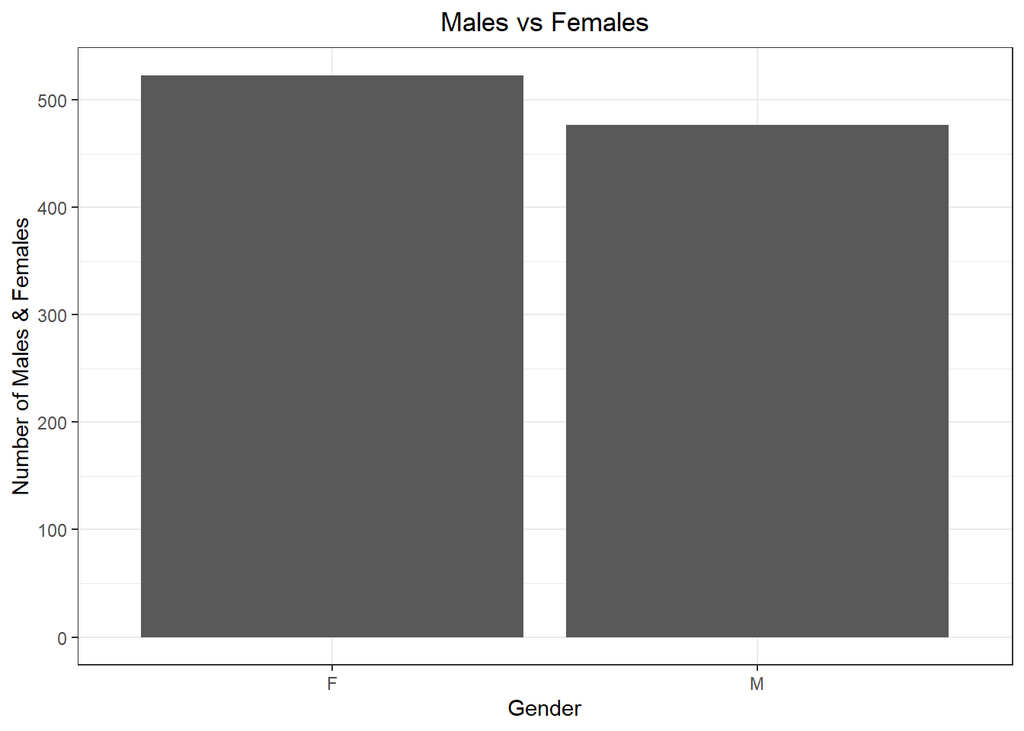

```r
df_new %>% group_by(y) %>% count() %>%
   mutate(y=as.factor(y)) %>%
  ggplot(aes(x=y , y=n))+
  geom_col()+labs(x="Gender",y="Number of Males & Females", fill= "Gender",title = "Males vs Females")+
  theme_bw()+
  theme(plot.title = element_text(hjust = 0.5))
```

3.2.5. Use mutate function to add sum of x per “M” and “F” and plot the results using sum of x per “M” and “F”. [5]

```r
xS<-sum(x)
```